# Visualización - COVID-19

Angel Mora

Marzo 2021

# Proyecto Análisis de Datos COVID

> > Objetivo: R básico + dplyr + ggplot2
- Importa dataset covid_19_data.csv
- Muestra las 5 primeras filas y quédate con las columnas siguientes:
- Si miras en el dataset hay que hacer algunas transformaciones. La primera:
  - Transforma los valores de la columna Pais-Region: *Mainland China* transforma a *China*, y *occupied Palestinian territory* a *Palestina*.

```
## # A tibble: 236,017 x 5
##    ObservationDate `Country/Region` Confirmed Deaths Recovered
##    <chr>           <chr>                <dbl>  <dbl>     <dbl>
##  1 01/22/2020      China                    1      0         0
##  2 01/22/2020      China                   14      0         0
##  3 01/22/2020      China                    6      0         0
##  4 01/22/2020      China                    1      0         0
##  5 01/22/2020      China                    0      0         0
##  6 01/22/2020      China                   26      0         0
##  7 01/22/2020      China                    2      0         0
##  8 01/22/2020      China                    1      0         0
##  9 01/22/2020      China                    4      0         0
## 10 01/22/2020      China                    1      0         0
## # … with 236,007 more rows
```

- Agrupar por pais-región y calcular la cuenta

```r
datacovid_por_dia
```

```
## # A tibble: 69,085 x 5
## # Groups:   Country/Region [226]
##    `Country/Region` ObservationDate Confirmed Deaths Recovered
##    <chr>            <chr>               <dbl>  <dbl>     <dbl>
##  1 ('St. Martin',)  03/10/2020              2      0         0
##  2 Afghanistan      01/01/2021          51526   2191     41727
##  3 Afghanistan      01/02/2021          51526   2191     41727
##  4 Afghanistan      01/03/2021          51526   2191     41727
##  5 Afghanistan      01/04/2021          53011   2237     42530
##  6 Afghanistan      01/05/2021          53105   2244     42666
##  7 Afghanistan      01/06/2021          53105   2244     42666
##  8 Afghanistan      01/07/2021          53207   2253     43291
##  9 Afghanistan      01/08/2021          53332   2257     43440
## 10 Afghanistan      01/09/2021          53400   2264     43740
## # … with 69,075 more rows
```

- Gráfico de los fallecimientos acumulados en España

> > Problema con las fechas. Añadir tres columnas - año, mes, día y convertir ObservationDate en columna llamada Fecha (de tipo fecha).

Ayuda: separar con `strsplit` y convertir a fecha con `as.Date`.

Esta función la puedes intentar después. Importa **datacovid_Spain.csv** y salta la modificación de la fecha.

Usarás la función algo así como lo siguiente:

```r
datacovid_por_dia_Spain <- convertir_a_fecha(datacovid_por_dia)
```

Tras convertir las fechas, acumular, etc. tendrás algo parecido a:

```r
datacovid_por_dia_Spain
```

```
## # A tibble: 393 x 4
##    ObservationDate Confirmed Recovered Deaths
##  * <date>              <dbl>     <dbl>  <dbl>
##  1 2020-02-01              1         0      0
##  2 2020-02-02              1         0      0
##  3 2020-02-03              1         0      0
##  4 2020-02-04              1         0      0
##  5 2020-02-05              1         0      0
##  6 2020-02-06              1         0      0
##  7 2020-02-07              1         0      0
##  8 2020-02-08              1         0      0
##  9 2020-02-09              2         0      0
## 10 2020-02-10              2         0      0
## # … with 383 more rows
```

Si no has podido hacer por ahora lo de la fecha, importa **datacovid_Spain.csv** y sigue con este dataset a partir de ahora.

- Visualiza las defunciones, los casos confirmados, y los recuperados por día (acumulados)

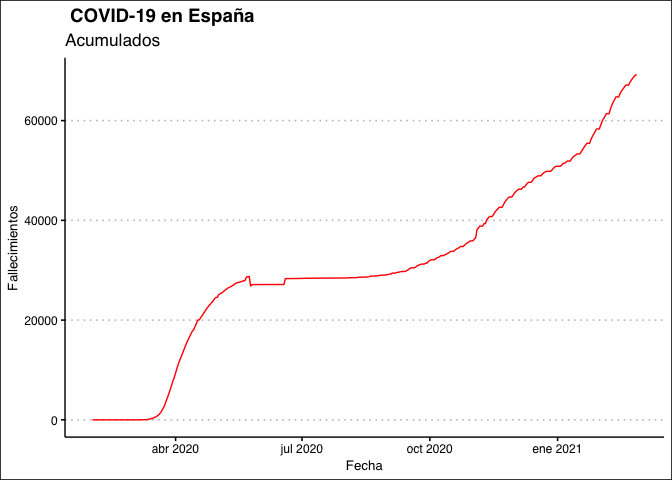

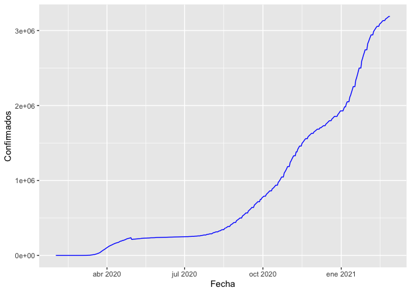

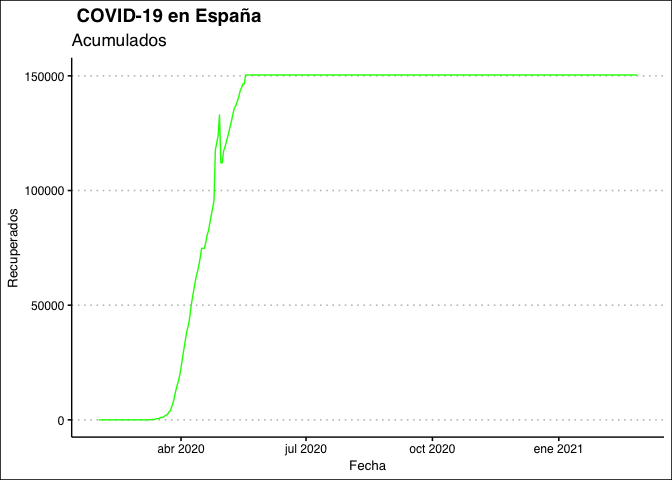

- Visualizar los casos acumulados en cada mes desde que comenzó la pandemia en China.
- Obtener una tabla con los los 20 paises con más fallecimientos y visualizar:
  - los fallecimientos acumulados, contagios acumulados y recuperaciones acumuladas para estos 20 paises
  - la evolución para estos 20 paises de los fallecimientos en la misma gráfica
  - la evolución para estos 20 paises de los contagios en la misma gráfica

> > Nota: recordar que en el dataset la información de fallecimientos ya está acumulada
- **Apartado libre**: Tenéis que utilizar el dataset para resolver algún problema relacionado con el COVID.
  - Analizar dataset para ver la información que tenemos
  - Plantear problema, cuestión, etc. (miraré que no haya preguntas distintas)
  - Realizar un análisis de datos completo para responder la cuestión planteada.